# STATS506_hw5

Author

Xingjian Liu

```r
knitr::opts_chunk$set(error=TRUE)
```

GitHub: https://github.com/CherryLIUxj/STATS506_proj/tree/master

## **Problem 1 - Plotting**

## (a)

Produce a graph of the **mean** monthly temperature in **celsius**. Draw a scatter-plot where the x-axis is month and the y-axis is the average monthly temperature in celsius. Add a line connecting the points within each season and color the lines and points by season (same color for lines and points in the same season). Be sure both x-axis and the legend are ordered appropriately, and that all labels/titles are clear and ready for publication (e.g. no variable names).

```r
nnmaps <- read.csv('chicago-nmmaps.csv')
```

```r
library(ggplot2)
library(dplyr)
```

```r
mean_monthly_temp <- nnmaps %>%
  mutate(temp_cels = (temp-30)*5/9) %>%
  group_by(month,month_numeric) %>%
  summarize(mean_temp_cels = mean(temp_cels, na.rm = TRUE),
            season=first(season)) %>%
  arrange(month_numeric)
```

```r
mean_monthly_temp$month <- factor(mean_monthly_temp$month,levels=c('Jan','Feb','Mar','Apr','May','Jun','Jul','Aug','Sep','Oct','Nov','Dec'))
```

```r
mean_monthly_temp
```

```
# A tibble: 12 × 4
# Groups:   month [12]
   month month_numeric mean_temp_cels season
   <fct>         <int>          <dbl> <chr>
 1 Jan               1         -3.09  Winter
 2 Feb               2          2.33  Winter
 3 Mar               3          5.23  Winter
 4 Apr               4         10.1   Spring
 5 May               5         17.1   Spring
 6 Jun               6         21.7   Spring
 7 Jul               7         24.7   Summer
 8 Aug               8         23.1   Summer
 9 Sep               9         19.6   Summer
10 Oct              10         13.7   Autumn
11 Nov              11          6.13  Autumn
12 Dec              12         -0.999 Autumn
```

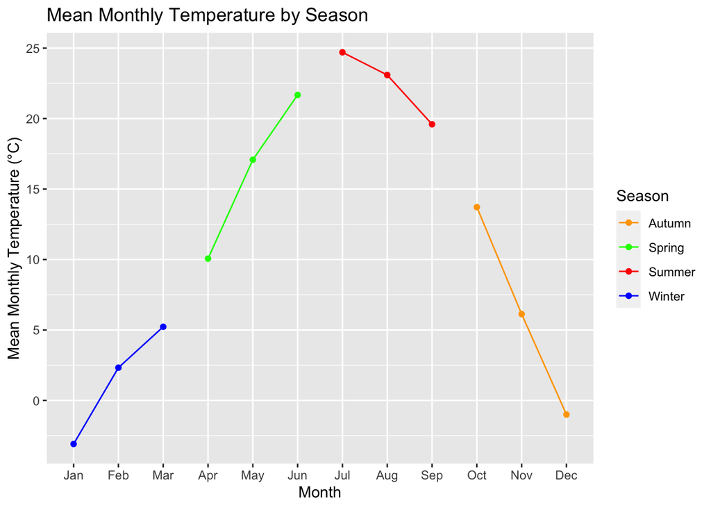

```r
ggplot(mean_monthly_temp, aes(x = month, y = mean_temp_cels, color = season, group = season)) +
  geom_point() +
  geom_line() +
  scale_color_manual(values = c("Winter" = "blue", "Spring" = "green",
                                "Summer" = "red", "Autumn" = "orange")) +
  labs(x = "Month", y = "Mean Monthly Temperature (°C)",
       title = "Mean Monthly Temperature by Season",
       color = "Season")
```

## (b)

Produce a similar plot with four sets of lines: mean monthly temperature in celsius, mean montly O3, mean monthly PM10, and mean monthly dewpoint. Figure out a way to distinguish between the four lines. Again, make sure the plot is publication-ready (clean and clear labels).

Use the plot to answer the following question:“Which of the four variables seems to have the least seasonal trend?”

```r
mean_monthly_params <- nnmaps %>%
  mutate(temp_cels = (temp-30)*5/9) %>%
  group_by(month,month_numeric) %>%
  summarize(mean_temp_cels = mean(temp_cels, na.rm = TRUE),
            mean_o3 = mean(o3, na.rm=TRUE),
            mean_pm10 = mean(pm10, na.rm=TRUE),
            mean_dewpoint = mean(dewpoint, na.rm=TRUE),
            season=first(season)) %>%
  arrange(month_numeric)
```

```r
mean_monthly_params$month <- factor(mean_monthly_params$month,levels=c('Jan','Feb','Mar','Apr','May','Jun','Jul','Aug','Sep','Oct','Nov','Dec'))
```

```r
mean_monthly_params
```

```
# A tibble: 12 × 7
# Groups:   month [12]
   month month_numeric mean_temp_cels mean_o3 mean_pm10 mean_dewpoint season
   <fct>         <int>          <dbl>   <dbl>     <dbl>         <dbl> <chr>
 1 Jan               1         -3.09    11.4       27.2          19.4 Winter
 2 Feb               2          2.33    16.1       27.7          27.6 Winter
 3 Mar               3          5.23    23.0       26.5          29.3 Winter
 4 Apr               4         10.1     22.2       30.8          35.8 Spring
 5 May               5         17.1     25.6       36.6          48.8 Spring
 6 Jun               6         21.7     27.9       35.3          58.3 Spring
 7 Jul               7         24.7     28.3       36.7          62.8 Summer
 8 Aug               8         23.1     23.0       32.9          62.3 Summer
 9 Sep               9         19.6     20.2       36.1          54.0 Summer
10 Oct              10         13.7     13.3       38.9          43.5 Autumn
11 Nov              11          6.13    10.4       30.0          32.0 Autumn
12 Dec              12         -0.999    9.32      26.1          21.9 Autumn
```

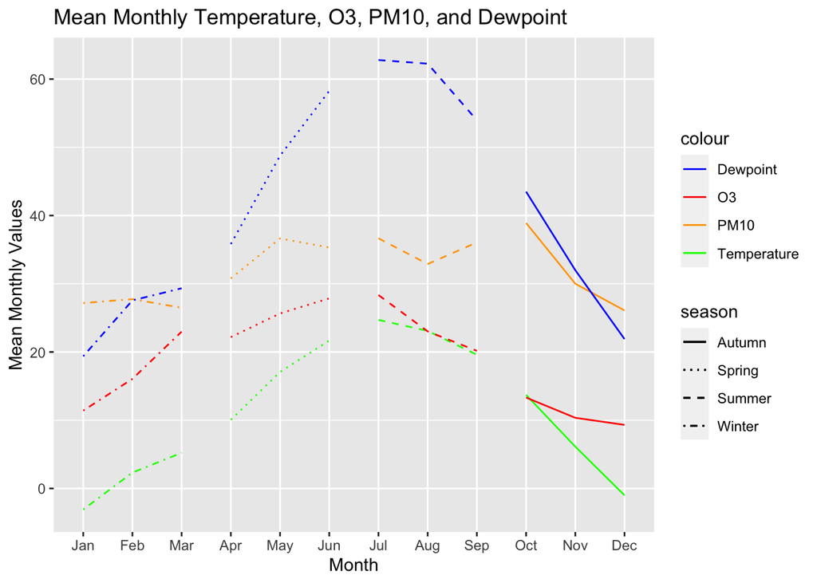

```r
ggplot(mean_monthly_params) +
  geom_line(aes(x = month, y = mean_temp_cels, group=season, color = 'Temperature', linetype=season)) +
  geom_line(aes(x = month, y = mean_o3, group=season,color = 'O3',linetype=season)) +
  geom_line(aes(x = month, y = mean_pm10, group=season, color = 'PM10',linetype=season)) +
  geom_line(aes(x = month, y = mean_dewpoint, group=season, color = 'Dewpoint', linetype=season)) +
  labs(title = "Mean Monthly Temperature, O3, PM10, and Dewpoint",
       x = "Month", y = "Mean Monthly Values") +
  scale_color_manual(values = c("blue", "red", "orange", "green")) +
  scale_linetype_manual(values = c('solid','dotted','dashed','dotdash'))
```

From the lot above, we can see that PM10 varies the least with month change, which means PM10 has the least seasonal trend

# Problem 2 - OOP

## a.

For the `poly` class, define the following:

- A constructor
- A validator
- A `show` method
- Addition and substraction

```r
library(methods)
```

```r
setClass("poly",
         slots = c(coefficient = "numeric", power = "numeric"))
```

constructor:

```r
make_poly <- function(coeff, power) {
    new("poly", coefficient = coeff, power = power)
}
```

validator:

```r
setValidity("poly", function(object) {
    if (length(object@coefficient) != length(object@power)) {
        stop("Lengths of coeffs and powers not equal")
    }
    return(TRUE)
})
```

```
Class "poly" [in ".GlobalEnv"]

Slots:

Name:  coefficient       power
Class:     numeric     numeric
```

`show` method:

```r
create_term <- function(coeff, power) {
    if (coeff == 0) {
      return(NULL)
    }
    term <- ""
    if (abs(coeff) != 1 || power == 0) {
      term <- paste0(term, coeff)
    }
    else if (coeff == -1) {
      term <- paste0(term, "-")
    }
    if (power == 1) {
      term <- paste0(term, "x")
    }
    else if (power != 0) {
      term <- paste0(term, "x^", power)
    }
    term
  }
```

```r
create_expr <- function(coeffs, powers) {
  terms <- mapply(create_term, coeffs, powers)
  expr <- paste(unlist(terms), collapse = " + ")
  gsub("\\+ -", " - ", expr)
}
```

```r
create_expr(c(2,3,-1,0,4,5,-3),c(3,-1,0,8,9,0,-1))
```

```
[1] "2x^3 + 3x^-1  - 1 + 4x^9 + 5  - 3x^-1"
```

```r
setMethod("show", "poly", function(object) {
    cat(create_expr(object@coefficient,object@power),'\n')
    return(invisible(object))
})
```

`Addition` method

```r
# Note: must use as.character(power) to access the names of new_coeff, or it will access the indices instead of names!

setMethod("+", signature(e1 ="poly",
                         e2 = "poly"),
          function(e1, e2) {
    powers <- unique(c(e1@power, e2@power))
    new_coeff <- numeric(length(powers))
    names(new_coeff) <- powers

    for (power in powers) {
        new_coeff[as.character(power)] <- sum(e1@coefficient[e1@power == power],
e2@coefficient[e2@power == power],
na.rm = TRUE)
    }

    new_power <- as.numeric(names(new_coeff))
    make_poly(new_coeff, new_power)
})
```

`subtraction` method

```r
setMethod("-", signature(e1 ="poly",
                         e2 = "poly"),
          function(e1, e2) {
    powers <- unique(c(e1@power, e2@power))
    new_coeff <- numeric(length(powers))
    names(new_coeff) <- powers

    for (power in powers) {
        new_coeff[as.character(power)] <- sum(e1@coefficient[e1@power == power],
-e2@coefficient[e2@power == power],
na.rm = TRUE)
    }

    new_power <- as.numeric(names(new_coeff))
    make_poly(new_coeff, new_power)
})
```

## b.

Use your poly class to run the following code:

```r
# 3x^2 + 2
p1 <- make_poly(c(3, 2), c(2, 0))
# 7x^3 - 2x^2 - x + 17
p2 <- make_poly(c(7, -2, -1, 17), c(3, 2, 1, 0))
p1
```

```
3x^2 + 2
```

```r
p2
```

```
7x^3  - 2x^2  - x + 17
```

```r
p1 + p2
```

```
x^2 + 19 + 7x^3  - x
```

```r
p1 - p2
```

```
5x^2  - 15  - 7x^3 + x
```

Note: In this case we require the user to input the simplified mathematical expression. For instance, we must not input make_poly(c(3, 2,1), c(2, 0,2)) since it can be simplified to make_poly(c(4, 2), c(2, 0))

# Problem 3 - Data Table

Install and load the package [**nycflights13**](https://cran.r-project.org/package=nycflights13).

## a.

Generate a table (which can just be a nicely printed tibble) reporting the mean and median departure delay per airport. Generate a second table (which again can be a nicely printed tibble) reporting the mean and median arrival delay per airport. *Exclude any destination with under 10 flights*. Do this exclusion through code, not manually.

Additionally,

- Order both tables in descending mean delay.
- Both tables should use the airport *names* not the airport *codes*.
- Both tables should print all rows.

**Note: I exclude observations with airport codes but without airport names, different from the PS #04 Solution.**

```r
library(nycflights13)
```

```r
library(data.table)
```

```r
flights_dt <- as.data.table(flights)
airports_dt <- as.data.table(airports)
planes_dt <- as.data.table(planes)
```

```r
dep_delay <- flights_dt[, .(
  mean_dep_delay = mean(dep_delay, na.rm = TRUE),
  median_dep_delay = median(dep_delay, na.rm = TRUE),
  total_flights = .N),
  by = .(origin)][total_flights>10][order(-mean_dep_delay)][airports_dt,.(name, mean_dep_delay, median_dep_delay),on=.(origin=faa),nomatch=0L]
```

```r
print(dep_delay)
```

```
                  name mean_dep_delay median_dep_delay
1: Newark Liberty Intl       15.10795               -1
2: John F Kennedy Intl       12.11216               -1
3:          La Guardia       10.34688               -3
```

```r
arr_delay <- flights_dt[, .(
  mean_arr_delay = mean(arr_delay, na.rm = TRUE),
  median_arr_delay = median(arr_delay, na.rm = TRUE),
  total_flights = .N),
  by = .(dest)][total_flights>10][airports_dt,.(name, mean_arr_delay, median_arr_delay),on=.(dest=faa),nomatch=0L][order(-mean_arr_delay)]
```

```r
print(arr_delay)
```

```
                                    name mean_arr_delay median_arr_delay
 1:                Columbia Metropolitan    41.76415094             28.0
 2:                           Tulsa Intl    33.65986395             14.0
 3:                    Will Rogers World    30.61904762             16.0
 4:                 Jackson Hole Airport    28.09523810             15.0
 5:                        Mc Ghee Tyson    24.06920415              2.0
 6:               Dane Co Rgnl Truax Fld    20.19604317              1.0
 7:                        Richmond Intl    20.11125320              1.0
 8:        Akron Canton Regional Airport    19.69833729              3.0
 9:                      Des Moines Intl    19.00573614              0.0
10:                   Gerald R Ford Intl    18.18956044              1.0
11:                      Birmingham Intl    16.87732342             -2.0
12:         Theodore Francis Green State    16.23463687              1.0
13: Greenville-Spartanburg International    15.93544304             -0.5
14:    Cincinnati Northern Kentucky Intl    15.36456376             -3.0
```

[output cut: 84 more lines]

## b.

How many flights did the aircraft model with the fastest average speed take? Produce a table with 1 row, and entires for the model, average speed (in MPH) and number of flights.

```r
# average speed = distance / time
# time = air_time (minute to hour)
fastest_model <- flights_dt[planes_dt, on = .(tailnum),nomatch=0L][, .(
  speed = mean(distance/(air_time/60), na.rm = TRUE),
  total_flights = .N), by = .(model)][order(-speed)][1]
```

```r
print(fastest_model)
```

```
     model    speed total_flights
1: 777-222 482.6254             4
```